# Natural Disasters Analysis - Number of People Affected

#### Authors: Women of the West Coast (WWC)

#### Date: Oct. 22, 2023

- Introduction
- Table of Contents
- Loading the Data
- Global Analysis
- Canada-Specific Analysis
- Conclusion

## Introduction

This report provides an in-depth analysis of the impact of various natural disasters, both globally and specific to Canada. The analysis is based on historical data from 1900 to 2010 and aims to offer insights that could inform the development and features of our team's mobile app for crisis response and management.

## Loading the Data

```python
import pandas as pd
import matplotlib.pyplot as plt

# Filter warnings
from warnings import filterwarnings
filterwarnings('ignore')
```

```python
# Load the dataset
raw_data = pd.read_csv('natural-disasters.csv')
```

```python
# Set display options to show all columns and rows
pd.set_option('display.max_columns', None)
pd.set_option('display.max_rows', None)
```

```python
# Display the first few rows of the dataset
raw_data.head()
```

|  | Entity | Year | Number of deaths from drought | Number of people injured from drought | Number of people affected from drought | Number of people left homeless from drought | Number of total people affected by drought | Reconstruction costs from drought | Insured damages against drought | Total economic damages from drought | Death rates from drought | Injury rates from drought | Number of people affected by drought per 100,000 | Homelessness rate from drought | Total number of people affected by drought per 100,000 | Number of deaths from earthquakes | Number of people injured from earthquakes | Number of people affected by earthquakes | Number of people left homeless from earthquakes | Number of total people affected by earthquakes | Reconstruction costs from earthquakes | Insured damages against earthquakes | Total economic damages from earthquakes | Death rates from earthquakes | Injury rates from earthquakes | Number of people affected by earthquakes per 100,000 | Homelessness rate from earthquakes | Total number of people affected by earthquakes per 100,000 | Number of deaths from disasters | … |
| --- | --- | --- | --- | --- | --- | --- | --- | --- | --- | --- | --- | --- | --- | --- | --- | --- | --- | --- | --- | --- | --- | --- | --- | --- | --- | --- | --- | --- | --- | --- |
| 0 | Afghanistan | 1950 | 0.0 | 0.0 | 0.0 | 0 | 0.0 | NaN | NaN | NaN | 0.0 | 0.0 | 0.000000 | 0 | 0.000000 | 210.0 | 200.0 | 0.0 | 0.0 | 200.0 | NaN | NaN | NaN | 2.572748 | 2.381236 | 0.000000 | 0.000000 | 2.381236 | 215.1 | … |
| 1 | Afghanistan | 1960 | 0.0 | 0.0 | 4800.0 | 0 | 4800.0 | 0.0 | 0.0 | 20.0 | 0.0 | 0.0 | 44.060951 | 0 | 44.060951 | 0.0 | 0.0 | 0.0 | 0.0 | 0.0 | 0.0 | 0.0 | 0.0 | 0.000000 | 0.000000 | 0.000000 | 0.000000 | 0.000000 | 10.7 | … |
| 2 | Afghanistan | 1970 | 0.0 | 0.0 | 0.0 | 0 | 0.0 | 0.0 | 0.0 | 0.0 | 0.0 | 0.0 | 0.000000 | 0 | 0.000000 | 6.1 | 1.5 | 9000.0 | 0.0 | 9001.5 | 0.0 | 0.0 | 0.0 | 0.047960 | 0.012722 | 69.535656 | 0.000000 | 69.548378 | 48.2 | … |
| 3 | Afghanistan | 1980 | 0.0 | 0.0 | 0.0 | 0 | 0.0 | 0.0 | 0.0 | 0.0 | 0.0 | 0.0 | 0.000000 | 0 | 0.000000 | 51.3 | 351.8 | 6244.0 | 658.0 | 7253.8 | 0.0 | 0.0 | 900.0 | 0.398499 | 2.742558 | 49.053053 | 5.248046 | 57.043657 | 58.3 | … |
| 4 | Afghanistan | 1990 | 0.0 | 0.0 | 0.0 | 0 | 0.0 | 0.0 | 0.0 | 0.0 | 0.0 | 0.0 | 0.000000 | 0 | 0.000000 | 742.6 | 358.3 | 27168.5 | 7702.5 | 35229.3 | 0.0 | 0.0 | 2001.0 | 3.814559 | 1.835906 | 146.665685 | 38.701410 | 187.203001 | 1038.9 | … |

```python
# Check the shape of the dataframe
raw_data.shape
```

```
(1604, 171)
```

We have 1604 rows and 171 columns in our dataset.

## Data Processing and Cleaning

Below are the data cleaning steps performed on the dataset:

1. Checking for missing values.
2. Checking for duplicate rows.

### Checking for missing values

```python
# Check for missing values
missing_values = raw_data.isnull().sum()

# Calculate the percentage of missing values for each column
missing_percentage = (missing_values / len(raw_data)) * 100

# Display columns with missing values and their corresponding percentage
missing_data = pd.DataFrame({'Missing Values': missing_values, 'Percentage': missing_percentage})
missing_data = missing_data[missing_data['Missing Values'] > 0].sort_values(by='Percentage', ascending=False)

missing_data
```

|  | Missing Values | Percentage |
| --- | --- | --- |
| Number of people affected by glacial lake outbursts per 100,000 | 1604 | 100.000000 |
| Death rates from glacial lake outbursts | 1604 | 100.000000 |
| Injury rates from storms | 1604 | 100.000000 |
| Death rates from storms | 1604 | 100.000000 |
| Total number of people affected by disasters per 100,000 | 1604 | 100.000000 |
| Total number of people affected by glacial lake outbursts per 100,000 | 1604 | 100.000000 |
| Homelessness rate from glacial lake outbursts | 1604 | 100.000000 |
| Injury rates from glacial lake outbursts | 1604 | 100.000000 |
| Insured damages against wildfires | 480 | 29.925187 |
| Total economic damages from wildfires | 480 | 29.925187 |
| Reconstruction costs from extreme temperatures | 480 | 29.925187 |
| Insured damages against extreme temperatures | 480 | 29.925187 |
| Total economic damages from extreme temperatures | 480 | 29.925187 |
| Reconstruction costs from glacial lake outbursts | 480 | 29.925187 |
| Insured damages against glacial lake outbursts | 480 | 29.925187 |
| Total economic damages from glacial lake outbursts | 480 | 29.925187 |
| Reconstruction costs from drought | 480 | 29.925187 |
| Total economic damages from fog | 480 | 29.925187 |
| Total economic damages from disasters as a share of GDP | 480 | 29.925187 |
| Total economic damages from drought as a share of GDP | 480 | 29.925187 |
| Total economic damages from earthquakes as a share of GDP | 480 | 29.925187 |
| Total economic damages from extreme temperatures as a share of GDP | 480 | 29.925187 |
| Total economic damages from floods as a share of GDP | 480 | 29.925187 |
| Total economic damages from landslides as a share of GDP | 480 | 29.925187 |
| Total economic damages from mass movements as a share of GDP | 480 | 29.925187 |
| Total economic damages from storms as a share of GDP | 480 | 29.925187 |
| Total economic damages from volcanic activity as a share of GDP | 480 | 29.925187 |
| Reconstruction costs from wildfires | 480 | 29.925187 |
| Reconstruction costs from fog | 480 | 29.925187 |
| Insured damages against fog | 480 | 29.925187 |
| Reconstruction costs from floods | 480 | 29.925187 |
| Total economic damages from drought | 480 | 29.925187 |
| Reconstruction costs from earthquakes | 480 | 29.925187 |
| Insured damages against earthquakes | 480 | 29.925187 |
| Total economic damages from earthquakes | 480 | 29.925187 |
| Reconstruction costs from disasters | 480 | 29.925187 |
| Insured damages against disasters | 480 | 29.925187 |
| Total economic damages from disasters | 480 | 29.925187 |
| Reconstruction costs from volcanic activity | 480 | 29.925187 |
| Insured damages against volcanic activity | 480 | 29.925187 |
| Total economic damages from volcanic activity | 480 | 29.925187 |
| Insured damages against floods | 480 | 29.925187 |
| Insured damages against drought | 480 | 29.925187 |
| Total economic damages from floods | 480 | 29.925187 |
| Reconstruction costs from mass movements | 480 | 29.925187 |
| Insured damages against mass movements | 480 | 29.925187 |
| Total economic damages from mass movements | 480 | 29.925187 |
| Reconstruction costs from storms | 480 | 29.925187 |
| Insured damages against storms | 480 | 29.925187 |
| Total economic damages from storms | 480 | 29.925187 |
| Reconstruction costs from landslides | 480 | 29.925187 |
| Insured damages against landslides | 480 | 29.925187 |
| Total economic damages from landslides | 480 | 29.925187 |
| Total economic damages from volcanic activity as a share of GDP.1 | 480 | 29.925187 |

For columns with 100% missing values, it's advisable to drop them as they don't add any value to the analysis.

#### Dropped columns with 100% missing values.

```python
# Drop columns with 100% missing values
data = raw_data.drop(columns=missing_data[missing_data['Percentage'] == 100].index)
```

#### Sanity Check after dropping

```python
# Re-check for missing values
missing_values = data.isnull().sum()

# Calculate the percentage of missing values for each column
missing_percentage = (missing_values / len(data)) * 100

# Display columns with missing values and their corresponding percentage
missing_data = pd.DataFrame({'Missing Values': missing_values, 'Percentage': missing_percentage})
missing_data = missing_data[missing_data['Missing Values'] > 0].sort_values(by='Percentage', ascending=False)

missing_data
```

|  | Missing Values | Percentage |
| --- | --- | --- |
| Reconstruction costs from drought | 480 | 29.925187 |
| Insured damages against glacial lake outbursts | 480 | 29.925187 |
| Insured damages against fog | 480 | 29.925187 |
| Total economic damages from fog | 480 | 29.925187 |
| Reconstruction costs from wildfires | 480 | 29.925187 |
| Insured damages against wildfires | 480 | 29.925187 |
| Total economic damages from wildfires | 480 | 29.925187 |
| Reconstruction costs from extreme temperatures | 480 | 29.925187 |
| Insured damages against extreme temperatures | 480 | 29.925187 |
| Total economic damages from extreme temperatures | 480 | 29.925187 |
| Reconstruction costs from glacial lake outbursts | 480 | 29.925187 |
| Total economic damages from glacial lake outbursts | 480 | 29.925187 |
| Insured damages against drought | 480 | 29.925187 |
| Total economic damages from disasters as a share of GDP | 480 | 29.925187 |
| Total economic damages from drought as a share of GDP | 480 | 29.925187 |
| Total economic damages from earthquakes as a share of GDP | 480 | 29.925187 |
| Total economic damages from extreme temperatures as a share of GDP | 480 | 29.925187 |
| Total economic damages from floods as a share of GDP | 480 | 29.925187 |
| Total economic damages from landslides as a share of GDP | 480 | 29.925187 |
| Total economic damages from mass movements as a share of GDP | 480 | 29.925187 |
| Total economic damages from storms as a share of GDP | 480 | 29.925187 |
| Total economic damages from volcanic activity as a share of GDP | 480 | 29.925187 |
| Reconstruction costs from fog | 480 | 29.925187 |
| Total economic damages from landslides | 480 | 29.925187 |
| Insured damages against landslides | 480 | 29.925187 |
| Reconstruction costs from landslides | 480 | 29.925187 |
| Total economic damages from drought | 480 | 29.925187 |
| Reconstruction costs from earthquakes | 480 | 29.925187 |
| Insured damages against earthquakes | 480 | 29.925187 |
| Total economic damages from earthquakes | 480 | 29.925187 |
| Reconstruction costs from disasters | 480 | 29.925187 |
| Insured damages against disasters | 480 | 29.925187 |
| Total economic damages from disasters | 480 | 29.925187 |
| Reconstruction costs from volcanic activity | 480 | 29.925187 |
| Insured damages against volcanic activity | 480 | 29.925187 |
| Total economic damages from volcanic activity | 480 | 29.925187 |
| Reconstruction costs from floods | 480 | 29.925187 |
| Insured damages against floods | 480 | 29.925187 |
| Total economic damages from floods | 480 | 29.925187 |
| Reconstruction costs from mass movements | 480 | 29.925187 |
| Insured damages against mass movements | 480 | 29.925187 |
| Total economic damages from mass movements | 480 | 29.925187 |
| Reconstruction costs from storms | 480 | 29.925187 |
| Insured damages against storms | 480 | 29.925187 |
| Total economic damages from storms | 480 | 29.925187 |
| Total economic damages from volcanic activity as a share of GDP.1 | 480 | 29.925187 |

No more columns with 100% missing values, great!

### Checking for duplicate rows

```python
# Check for duplicate rows
duplicate_rows = data.duplicated().sum()

duplicate_rows
```

```
0
```

The dataset doesn't have any duplicate rows.

## Global Analysis

We begin by examining the global impact of four major types of natural disasters: earthquakes, floods, storms, and wildfires.

```python
# Relevant columns for each disaster type
columns_of_interest = {
    "earthquake": [
        "Number of deaths from earthquakes",
        "Number of people injured from earthquakes",
        "Number of people left homeless from earthquakes",
        "Number of total people affected by earthquakes"
    ],
    "flood": [
        "Number of deaths from floods",
        "Number of people injured from floods",
        "Number of people left homeless from floods",
        "Number of total people affected by floods"
    ],
    "storm": [
        "Number of deaths from storms",
        "Number of people injured from storms",
        "Number of people left homeless from storms",
        "Number of total people affected by storms"
    ],
    "wildfire": [
        "Number of deaths from wildfires",
        "Number of people injured from wildfires",
        "Number of people left homeless from wildfires",
        "Number of total people affected by wildfires"
    ]
}


# Extract the relevant columns
filtered_data = data[["Entity", "Year"] + [col for sublist in columns_of_interest.values() for col in sublist]]

# Display the first few rows of the filtered dataset
filtered_data.head()
```

|  | Entity | Year | Number of deaths from earthquakes | Number of people injured from earthquakes | Number of people left homeless from earthquakes | Number of total people affected by earthquakes | Number of deaths from floods | Number of people injured from floods | Number of people left homeless from floods | Number of total people affected by floods | Number of deaths from storms | Number of people injured from storms | Number of people left homeless from storms | Number of total people affected by storms | Number of deaths from wildfires | Number of people injured from wildfires | Number of people left homeless from wildfires | Number of total people affected by wildfires |
| --- | --- | --- | --- | --- | --- | --- | --- | --- | --- | --- | --- | --- | --- | --- | --- | --- | --- | --- |
| 0 | Afghanistan | 1950 | 210.0 | 200.0 | 0.0 | 200.0 | 5.1 | 0.0 | 0.0 | 0.0 | 0.0 | 0.0 | 0.0 | 0.0 | 0.0 | 0.0 | 0.0 | 0.0 |
| 1 | Afghanistan | 1960 | 0.0 | 0.0 | 0.0 | 0.0 | 10.7 | 0.0 | 0.0 | 0.0 | 0.0 | 0.0 | 0.0 | 0.0 | 0.0 | 0.0 | 0.0 | 0.0 |
| 2 | Afghanistan | 1970 | 6.1 | 1.5 | 0.0 | 9001.5 | 32.1 | 14.0 | 750.0 | 60168.4 | 0.0 | 0.0 | 0.0 | 0.0 | 0.0 | 0.0 | 0.0 | 0.0 |
| 3 | Afghanistan | 1980 | 51.3 | 351.8 | 658.0 | 7253.8 | 0.0 | 0.0 | 0.0 | 19100.0 | 0.0 | 0.0 | 0.0 | 0.0 | 0.0 | 0.0 | 0.0 | 0.0 |
| 4 | Afghanistan | 1990 | 742.6 | 358.3 | 7702.5 | 35229.3 | 199.0 | 30.0 | 1765.0 | 18230.5 | 1.0 | 0.0 | 0.0 | 0.0 | 0.0 | 0.0 | 0.0 | 0.0 |

```python
# Aggregate the data for each disaster type over the years
global_aggregated_data = {}

for disaster, columns in columns_of_interest.items():
    if columns:
        global_aggregated_data[disaster] = filtered_data[columns].sum()

# Transform the aggregated data to the desired format
transformed_data = {}

for disaster, stats in global_aggregated_data.items():
    transformed_data[disaster.capitalize()] = {
        "Deaths": f"{int(stats[0]):,}",
        "People injured": f"{int(stats[1]):,}",
        "People left homeless": f"{int(stats[2]):,}",
        "Total people affected": f"{int(stats[3]):,}"
    }

# Convert the dictionary to a DataFrame for display
transformed_df = pd.DataFrame(transformed_data).transpose()

transformed_df.T
```

|  | Earthquake | Flood | Storm | Wildfire |
| --- | --- | --- | --- | --- |
| Deaths | 905,683 | 2,793,814 | 559,132 | 1,750 |
| People injured | 1,117,359 | 545,990 | 556,190 | 4,455 |
| People left homeless | 9,954,741 | 36,963,619 | 21,588,466 | 96,016 |
| Total people affected | 80,044,254 | 1,536,563,304 | 474,296,923 | 6,860,637 |

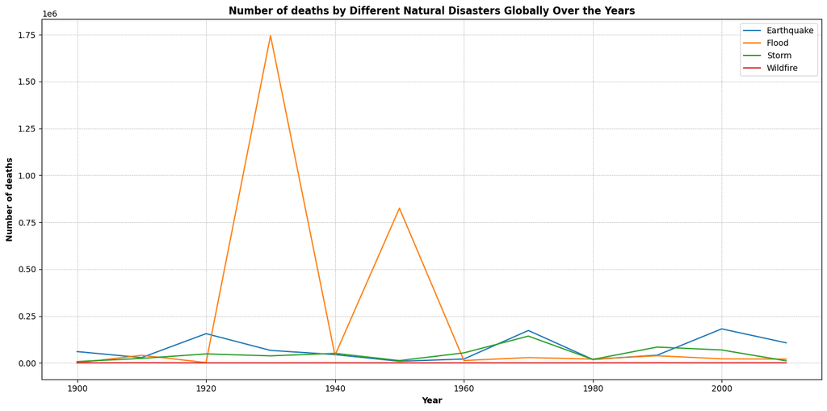

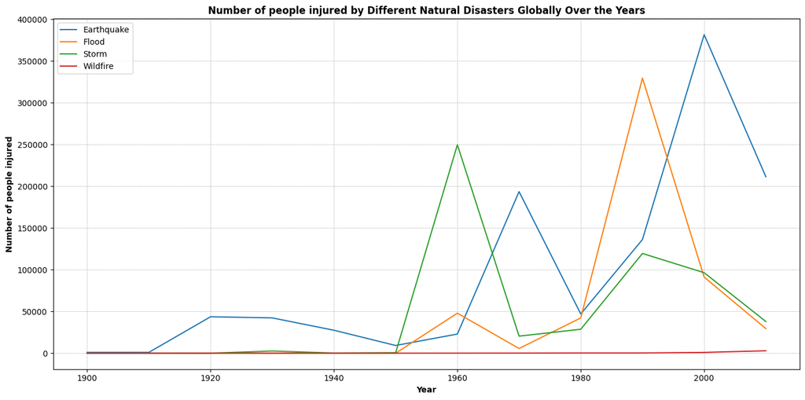

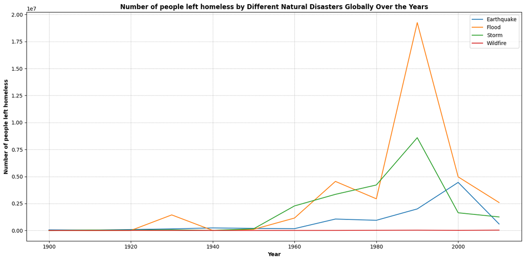

```python
# Metric names to match the column names
metrics = {
    "Number of deaths": [
        "Number of deaths from earthquakes",
        "Number of deaths from floods",
        "Number of deaths from storms",
        "Number of deaths from wildfires"
    ],
    "Number of people injured": [
        "Number of people injured from earthquakes",
        "Number of people injured from floods",
        "Number of people injured from storms",
        "Number of people injured from wildfires"
    ],
    "Number of people left homeless": [
        "Number of people left homeless from earthquakes",
        "Number of people left homeless from floods",
        "Number of people left homeless from storms",
        "Number of people left homeless from wildfires"
    ]
}

# Function to plot data for specified column and region (Global/Canada)
def plot_disaster_data(columns, region, title_suffix):
    plt.figure(figsize=(14, 7))

    if region == "Global":
        data_to_plot = filtered_data.groupby('Year').sum()
    else:
        data_to_plot = canada_data.groupby('Year').sum()

    # Disaster types
    disasters = ["earthquake", "flood", "storm", "wildfire"]

    # Plotting data for each disaster type
    for i, disaster in enumerate(disasters):
        plt.plot(data_to_plot.index, data_to_plot[columns[i]], label=disaster.capitalize())

    # Labeling the graph
    metric = columns[0].split(" from ")[0]
    plt.title(f"{metric} by Different Natural Disasters {title_suffix}", fontweight='bold')
    plt.ylabel(metric, fontweight='bold')
    plt.xlabel('Year', fontweight='bold')
    plt.legend()
    plt.grid(True, which='both', linestyle='--', linewidth=0.5)
    plt.tight_layout()
    plt.show()

# Plotting data globally
for metric, columns in metrics.items():
    plot_disaster_data(columns, "Global", "Globally Over the Years")
```

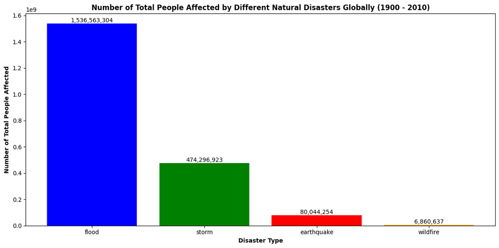

```python
# Define the bars (natural disasters) and associated colors
bars = ["earthquake", "flood", "storm", "wildfire"]
colors = ["red", "blue", "green", "orange"]

# Aggregate the data for each disaster type globally
global_heights = [
    data['Number of total people affected by earthquakes'].sum(),
    data['Number of total people affected by floods'].sum(),
    data['Number of total people affected by storms'].sum(),
    data['Number of total people affected by wildfires'].sum()
]

# Sorting the data from most to least affected for global data
sorted_indices_global = sorted(range(len(global_heights)), key=lambda k: global_heights[k], reverse=True)
sorted_heights_global = [global_heights[i] for i in sorted_indices_global]
sorted_bars_global = [bars[i] for i in sorted_indices_global]
sorted_colors_global = [colors[i] for i in sorted_indices_global]

# Determine the timeframe from the global data
timeframe = f"{filtered_data['Year'].min()} - {filtered_data['Year'].max()}"

# Plotting the sorted data for global data with adjusted title and labels
plt.figure(figsize=(12, 6))
bars_plot_global = plt.bar(sorted_bars_global, sorted_heights_global, color=sorted_colors_global)

# Adding labels with rounded numbers to the bars for global data
for bar in bars_plot_global:
    yval = bar.get_height()
    plt.text(bar.get_x() + bar.get_width()/2, yval, f"{int(yval):,}", ha='center', va='bottom', fontsize=10)

plt.title(f'Number of Total People Affected by Different Natural Disasters Globally ({timeframe})', fontweight='bold')
plt.ylabel('Number of Total People Affected', fontweight='bold')
plt.xlabel('Disaster Type', fontweight='bold')
plt.tight_layout()
plt.show()
```

### Insights for Global Analysis:

- **Floods** have affected the most significant number of people globally, with over 1 billion people impacted over the specified timeframe. Floods can be devastating, often impacting large areas and causing significant property and agricultural damage.
- **Storms** have affected nearly half a billion people globally. This indicates that storms are not only frequent but also have a vast reach, affecting large populations.
- **Earthquakes** have impacted slightly above 80 million people. While earthquakes might not be as frequent as storms or floods, their severity can be high, leading to massive casualties and displacement.
- **Wildfires** have the least impact in terms of the number of people affected globally, but still with over 6 million people. It's crucial to understand that wildfires can cause significant property damage and ecological impacts, even if fewer people are directly affected.

This global perspective is essential to understand the broader context of natural disasters. However, for specific applications, it might be vital to delve deeper into regional or country-specific data, as the intensity and frequency of these disasters can vary significantly based on geographical factors.

**Therefore, with a global perspective established, we now turn our focus to Canada.**

## Canada-Specific Analysis

```python
# Filter the data for Canada
canada_data = filtered_data[filtered_data['Entity'] == 'Canada']

# Aggregate the data for each disaster type for Canada only
canada_aggregated_data = {}

for disaster, columns in columns_of_interest.items():
    if columns:
        canada_aggregated_data[disaster] = canada_data[columns].sum()

# Transform the aggregated data to the desired format with disaster types in columns
transformed_canada_data = {}

for disaster, stats in canada_aggregated_data.items():
    transformed_canada_data[disaster.capitalize()] = {
        "Deaths": f"{int(stats[0]):,}",
        "People injured": f"{int(stats[1]):,}",
        "People left homeless": f"{int(stats[2]):,}",
        "Total people affected": f"{int(stats[3]):,}"
    }

# Convert the dictionary to a DataFrame for display
transformed_df_canada = pd.DataFrame(transformed_canada_data)

transformed_df_canada
```

|  | Earthquake | Flood | Storm | Wildfire |
| --- | --- | --- | --- | --- |
| Deaths | 2 | 5 | 30 | 11 |
| People injured | 0 | 0 | 88 | 0 |
| People left homeless | 0 | 1,200 | 453 | 1,823 |
| Total people affected | 0 | 33,078 | 1,651 | 22,007 |

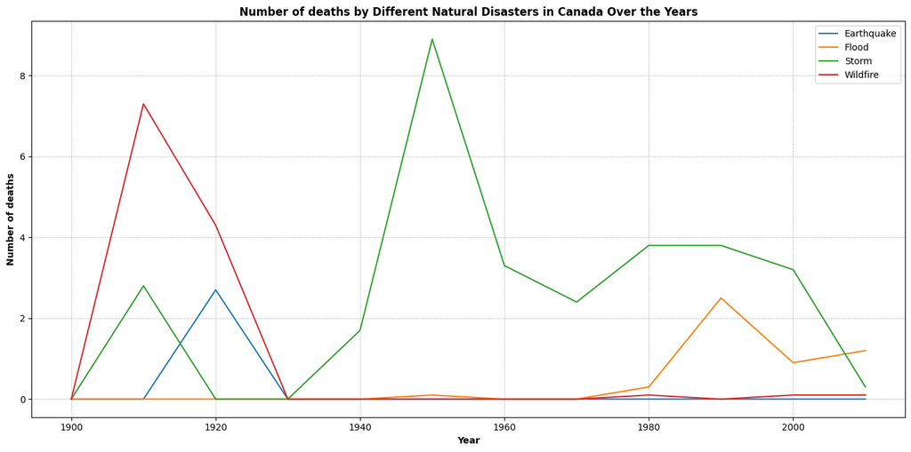

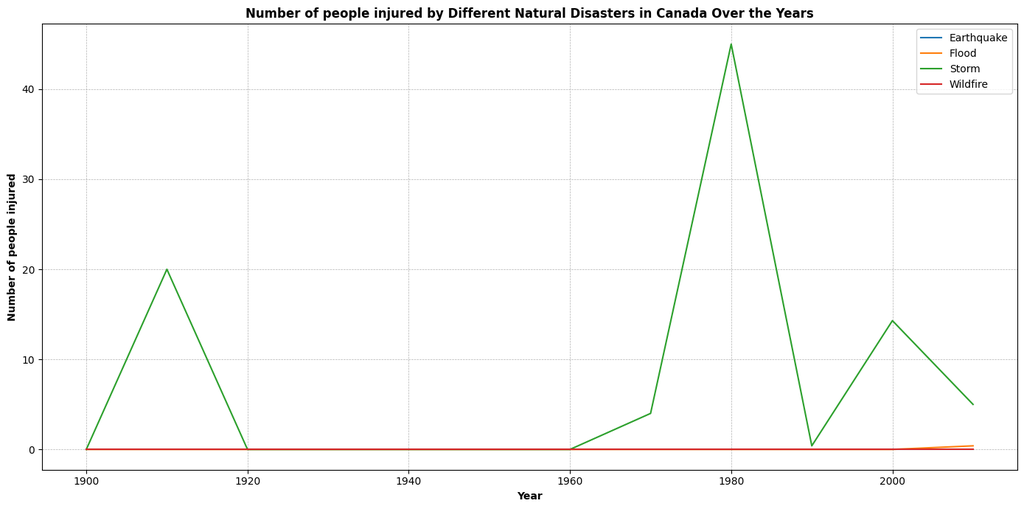

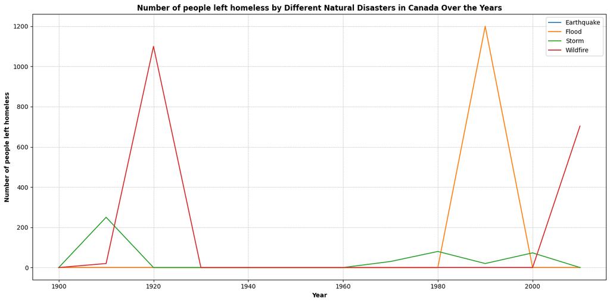

```python
# Using the metrics and plot_disaster_data function defined in the previous code section for global data

# Plotting data for Canada
for metric, columns in metrics.items():
    plot_disaster_data(columns, "Canada", "in Canada Over the Years")
```

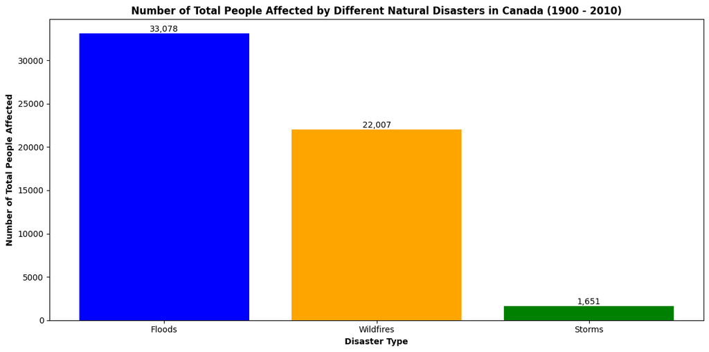

```python
# Regenerate the canada_aggregated_df dataframe
canada_data_filtered = data[data['Entity'] == 'Canada']
canada_aggregated_data = {
    'flood': canada_data_filtered['Number of total people affected by floods'].sum(),
    'storm': canada_data_filtered['Number of total people affected by storms'].sum(),
    'wildfire': canada_data_filtered['Number of total people affected by wildfires'].sum()
}
canada_aggregated_df = pd.DataFrame.from_dict(canada_aggregated_data, orient='index', columns=['Total Affected'])

# Data for the bar graph
heights = [
    canada_aggregated_df['Total Affected']['flood'],
    canada_aggregated_df['Total Affected']['storm'],
    canada_aggregated_df['Total Affected']['wildfire']
]
bars = ['Floods', 'Storms', 'Wildfires']
colors = ['blue', 'green', 'orange']

# Sorting the data from most to least affected
sorted_indices = sorted(range(len(heights)), key=lambda k: heights[k], reverse=True)
sorted_heights = [heights[i] for i in sorted_indices]
sorted_bars = [bars[i] for i in sorted_indices]
sorted_colors = [colors[i] for i in sorted_indices]

# Plotting the sorted data
plt.figure(figsize=(12, 6))
bars_plot = plt.bar(sorted_bars, sorted_heights, color=sorted_colors)

# Adding labels with rounded numbers to the bars
for bar in bars_plot:
    yval = bar.get_height()
    plt.text(bar.get_x() + bar.get_width()/2, yval, f"{int(yval):,}", ha='center', va='bottom', fontsize=10)

plt.title(f'Number of Total People Affected by Different Natural Disasters in Canada ({timeframe})', fontweight='bold')
plt.ylabel('Number of Total People Affected', fontweight='bold')
plt.xlabel('Disaster Type', fontweight='bold')
plt.tight_layout()
plt.show()
```

### Insights for Canada-Specific Analysis:

The bar chart provides an aggregated view of the total number of people affected by each disaster type in Canada:

- **Floods** stand out as the most impactful natural disaster in Canada, affecting over 30,000 people. The impact of floods is consistent with the global trends we observed earlier, but the emphasis here indicates that Canada might be particularly prone to flood-related incidents.
- **Wildfires** are the second most impactful disaster type in Canada. Although globally wildfires affected the least significant number of people, in Canada, they come right after floods in terms of the total affected population. Also, it's important to note that the actual spatial extent and ecological damage of wildfires can be significant.
- **Storms** have had a relatively minor impact in Canada in terms of the number of people affected. This might suggest that while Canada experiences storms, they might not be as devastating or as frequent as in some other regions.

These insights provide a comprehensive view of the impact of natural disasters in Canada, informing the development and features of the mobile app.

## Conclusion

The analysis provides valuable insights into the impact of natural disasters, both globally and in Canada. Understanding these patterns and trends can inform strategies for crisis response and management. The data emphasizes the significance of floods and wildfires, especially in affecting large populations in Canada. This information is crucial for prioritizing resources, designing preventive measures, and developing responsive solutions such as our proposed mobile app.